```python
%matplotlib inline
```

# Demonstration of Python Reconstruction Operators in Neural Networks (Pyro-NN)

In this notebook, we will demonstrate the capabilities of Pyro-NN, a differentiable reconstruction framework. The notebook is structured into four main parts:

1. **Introduction to Pyro-NN**: Gain a basic understanding of the theory behind Pyro-NN.
2. **Installation and Setup**: Learn how to install and set up Pyro-NN on your machine.
3. **Working with Projection Data**: Explore how to work with projection data to initiate a reconstruction.
4. **Advanced Examples**: Discover more advanced examples showcasing the usage of Pyro-NN.

## 1. Introduction to Pyro-NN

**1.1 Motivation**

- We can make use of known operators

[figure not shown]

- For Deep Learning, the loss function and the amount of parameters to train can be reduced
- We can have gradient flow through different domains
- Parts of the neural network get interpretable, e.g. as filter

**1.2 Basic overview**

[figure not shown]

**1.3. General Notes**

- Supports Tensorflow and PyTorch
- Full GPU Integration
- Open Source
- Apache 2.0 License

## 2. Installation and Setup

**2.1. Installation**

Pyro-NN can be used with two of the most powerful Python libraries for machine learning, namely PyTorch and TensorFlow. In this notebook, we will focus on using Pyro-NN with PyTorch.

The latest version of Pyro-NN can be found in the [GIT Repository](https://git01.iis.fhg.de/lschneid/pyro-nn-torch/-/tree/torch?ref_type=heads). To gain access, please send an email to Linda (linda-sophie.schneider@iis-extern.fraunhofer.de) or Yipeng (yipeng.sun@iis-extern.fraunhofer.de).

To install Pyro-NN, the following requirements must be met:

- Microsoft Visual Studio (in case you want to build it yourself)
- Microsoft Visual C++ 14.0 or greater
- Installation of the Python package "build"
- CUDA version greater than 10.2

Once all of these requirements are fulfilled, follow these steps:

1. Clone the repository and switch to the "torch" branch using the command: `git checkout torch`
2. Run the command: `python -m build .` (on Linux: `python3 -m build .`)
3. Switch to the newly created sub-directory "dist"
4. Build the wheel using the following command: `pip install pyronn-(*version_number*).whl`

If necessary, you can modify the `pyproject.toml` file to specify a particular torch version. However, be cautious and only make changes if you are confident in what you are doing!

**2.2. Integration into your Python Script**

```python
import torch
import pyronn
import numpy as np
```

**2.3. Internal Structure**

The methodology of Pyro-NN is contained within the "ct_reconstruction" folder. This folder is divided into four main parts:

1. **Geometry**: Defines the scanning parameters and trajectory.
   - Initialization from parameters: Possible if you know all your scanning parameters and your scanning trajectory was a circle.
   - Initialization from EZRT Header: Automatic setup of the scanning environment, since positioning is known also possible for arbitrary trajectories.
   - => Small Hint: Sometimes Parameters in the Header are filled wrong by XSimulation and/or Firefly. Errors can still occure!
2. **Layers**: Contains the definitions of the 2D and 3D forward/backward projectors.
   - For initializing these layers, the geometry of the scan need to be defined.
   - Input of all layers is the Image-Tensor (from the respective dimension) and a geometry dict, returned when initializing the geometry.
   - For 2D: Parallel Beam and Fan Beam are implemented.
   - For 3D: Cone Beam is implemented.
3. **Helpers**: Provides pre-implemented filters, weights, trajectories, and phantoms.
   - Implemented filter: Ramp Filters, Ram Lak, Shepp Logan, Cosine, Hamming, Hann
   - Implemented weights: Cosine, Parker
   - Implemented trajectories: circular and arbitrary
4. **Cores**: Stores the kernels and the torch connection.

## 3. Working with Projection Data

We will demonstrate an example of reconstructing from the EZRT Header. To begin, we load the projections with Pytorch.

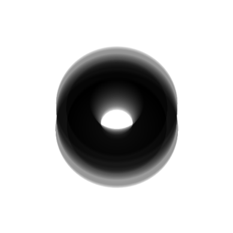

```python
from PythonTools import raw2py
import matplotlib.pyplot as plt
from get_natsorted_images import get_images_sorted
from PIL import Image
import torchvision.transforms as transforms

# Define folder and load image natually sorted.
projection_folder = r"D:\simulated_data\circ_diff_reco_test\0001581_partstudio_00_model_ste_00_2048"
projection_paths = get_images_sorted(projection_folder)
images = list()
headers = list()
# Define basic transformation to get projections as tensors and with data range (0,1)
transform = transforms.Compose([transforms.ToTensor(), transforms.Normalize(0, 65535,inplace = True)]) #For Range -1,1 : (32767.5, 32767.5)
for i,proj in enumerate(projection_paths):
    header, img = raw2py.raw2py(proj,switch_order=True)
    img = Image.fromarray(img)
    # Convert image to float before normalization
    img = img.convert('F')
    images.append(transform(img).float())
    headers.append(header)

# Visualization of the images
# Create the figure and axis object
fig, ax = plt.subplots()

# Load a single image, transform to numpy array for plotting
image = images[5].cpu().squeeze().detach().numpy()

# Display the image
plt.figure()
ax.imshow(image, cmap="gray")
ax.axis('off')

# Show the figure
plt.show()
```

As a next step, we have to initialize the geometry of our scan. If we have an EZRT Header available, we can use the informations of the header.

```python
from pyronn.ct_reconstruction.geometry.geometry import Geometry
geom = Geometry()
# Volume shape in Voxel, Volume spacing in mm
geom.init_from_EZRT_header(projection_headers =headers,volume_shape=[300,300,300],volume_spacing=0.5)
```

```
circ
circ
```

Since we already have some projections available, let's build a sinogram. In future, the following method should be included in the Pyro-NN Package:

```python
def build_sinogram(images):
    n = len(images)
    nc = 1
    _, width, height = images[0].size()
    transformed_images = torch.zeros((nc, n, height, width), dtype=torch.float32)
    # 0 you get when you input 1. in a log function. The maximum value not being infinity is torch.finfo(torch.float32).eps
    transform = transforms.Compose([ transforms.Normalize(0,5)]) #-torch.log(torch.tensor(torch.finfo(torch.float32).eps))
    for i in range(0, n):
        transformed_images[:, i, :, :] = transform(-torch.log(images[i].float()))
    return transformed_images

sinogram = build_sinogram(images=images).cuda()

print("Shape of Sinogram: ",sinogram.shape)
print("Minimum Value in Sinogram: ",sinogram.flatten().min())
print("Maximum Value in Sinogram: ",sinogram.flatten().max())
```

```
Shape of Sinogram:  torch.Size([1, 90, 512, 512])
Minimum Value in Sinogram:  tensor(0.0055, device='cuda:0')
Maximum Value in Sinogram:  tensor(0.7568, device='cuda:0')
```

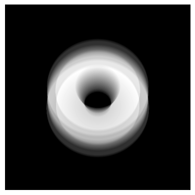

```python
# Visualization of the log transformed sinogram
# Create the figure and axis object
fig, ax = plt.subplots()

# Load a single image, transform to numpy array for plotting
image = sinogram[0][5].cpu().squeeze().detach().numpy()

# Display the image
plt.figure()
ax.imshow(image, cmap="gray")
ax.axis('off')

# Show the figure
plt.show()
```

Next, we need to initialize the reconstruction layer. For presentation purpose, we initialize all implemented layers.

```python
from pyronn.ct_reconstruction.layers.backprojection_3d import ConeBackProjection3D
from pyronn.ct_reconstruction.layers.projection_3d import ConeProjection3D
from pyronn.ct_reconstruction.layers.projection_2d import FanProjection2D,ParallelProjection2D
from pyronn.ct_reconstruction.layers.backprojection_2d import FanBackProjection2D,ParallelBackProjection2D

# Cone Beam 3D Forward and Backward Projector
coneForwardProjection3D = ConeProjection3D(hardware_interp=True) # Reconstruction -> Sinogram
coneBackwardProjection3D = ConeBackProjection3D(hardware_interp=True) # Sinogram -> Reconstruction

# Fan Beam 2D Forward and Backward Projector
fanForwardProjection2D = FanProjection2D() # Reconstruction -> Sinogram
fanBackwardProjection2D = FanBackProjection2D() # Sinogram -> Reconstruction

# Parallel Beam 2D Forward and Backward Projector
parallelForwardProjection2D = ParallelProjection2D() # Reconstruction -> Sinogram
parallelBackwardProjection2D = ParallelBackProjection2D() # Sinogram -> Reconstruction
```

With all of those initialized, we can start reconstructing our projections. Hence, we will perform a basic filtered backprojection for a circular scan.

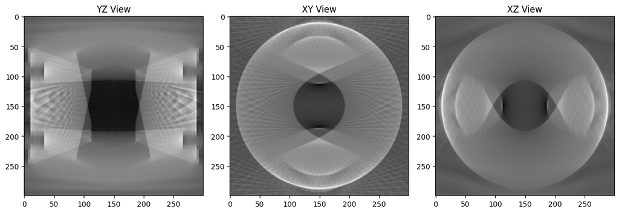

```python
from pyronn.ct_reconstruction.helpers.filters.filters import ramp, ramp_3D, ram_lak_3D, shepp_logan_3D
from visualize_reconstruction import show_reco_views
from pyronn.ct_reconstruction.helpers.phantoms import shepp_logan

def FBP_ConeBeam(sinogram,geometry):
    reco_filter = torch.tensor(shepp_logan_3D(geometry.detector_shape,geometry.detector_spacing,geometry.number_of_projections),dtype=torch.float32).cuda()
    # Filter Sinogram in Fourier Domain
    x = torch.fft.fft(sinogram.cuda(),dim=-1,norm="ortho")
    x = torch.multiply(x,reco_filter)
    x = torch.fft.ifft(x,dim=-1,norm="ortho").real

    # Reconstruction
    reconstruction = coneBackwardProjection3D.forward(x.contiguous(), **geometry)

    return reconstruction

reconstruction = FBP_ConeBeam(sinogram,geom)
show_reco_views(reconstruction,geom)
```

## 4. Advanced Examples

**4.1 Iterative Reconstruction**

[figure not shown]

```python
def Iterative_reconstruction(sinogram, geometry, num_iterations):
    current_sino = None
    reco = torch.nn.Parameter(torch.unsqueeze(torch.full(size = geometry.volume_shape,fill_value=0.0, dtype=torch.float32), dim=0).float(),requires_grad=False).cuda()
    for i in range(num_iterations):
        current_sino = coneForwardProjection3D(reco,**geometry)

        #normalize current sinogram
        min_cs, max_cs = torch.min(current_sino.flatten()), torch.max(current_sino.flatten())
        if (max_cs - min_cs) != 0:
            current_sino=current_sino + min_cs
            current_sino = current_sino /(max_cs-min_cs)

        # calculate difference
        current_sino= current_sino - sinogram
        update = torch.multiply(2/(i+1),coneBackwardProjection3D(current_sino,**geometry))
        reco = reco -update

    return reconstruction

reconstruction = Iterative_reconstruction(sinogram,geom,18)
show_reco_views(reconstruction,geom)
```

[output not shown]